# Kaggle Twitter Sentiment Analysis

hbmaclean

2025-08-22

# 1 Introduction

Below is a description of the **Twitter Sentiment Analysis Dataset** from [Kaggle](https://www.kaggle.com/datasets/jp797498e/twitter-entity-sentiment-analysis/data).

> **Overview**

> This is an entity-level sentiment analysis dataset of twitter. Given a message and an entity, the task is to judge the sentiment of the message about the entity. There are three classes in this dataset: Positive, Negative and Neutral. We regard messages that are not relevant to the entity (i.e. Irrelevant) as Neutral.

> **Usage**

> Please use `twitter_training.csv` as the training set and `twitter_validation.csv` as the validation set. Top 1 classification accuracy is used as the metric.

# 2 Importing Packages

```r
library(data.frame.X)
install_packages(c(
    'curl', 'stringr', 'dplyr', 'tidyr', 'caret', 'tibble', 'kableExtra', 'DT',
    'syuzhet', 'ranger', 'randomForest', 'devtools'
))

install_github('munoztd0/reprtree')
eval(substitute(library(pkg), list(pkg='reprtree')))
library(reprtree)

set.seed(45245)
```

# 3 Fetching the Data

In this case, the data is pre-partitioned into training and validation. This downloads the zip and extracts and reads each CSV into a data.frame. Given the note in the data description above, this also mutates “irrelevant” to “neutral”.

```r
fetch_data <- function() {
    options(timeout = 120)
    url <- paste0(
        'https://www.kaggle.com/api/v1/datasets/download/',
        'jp797498e/twitter-entity-sentiment-analysis'
    )
    tmp <- tempfile()
    curl_download(url, tmp)
    cols <- c('id', 'entity', 'sentiment', 'content')
    train_df <<- as.data.frame(
        read.csv(
            unz(tmp, 'twitter_training.csv'),
            header = FALSE,
            col.names = cols
        )
    ) |>
        mutate(sentiment = ifelse(sentiment == 'Irrelevant', 'Neutral', sentiment))

    test_df <<- as.data.frame(
        read.csv(
            unz(tmp, 'twitter_validation.csv'),
            header = FALSE,
            col.names = cols
        )
    ) |>
        mutate(sentiment = ifelse(sentiment == 'Irrelevant', 'Neutral', sentiment))

}
fetch_data()
sample_n(test_df, 5) |> union_all(sample_n(train_df, 5)) |>
    datatable(rownames = FALSE, options = list(dom = 't', pageLength = nrow(.data)))
```

| id | entity | sentiment | content |
| --- | --- | --- | --- |
| 11760 | Verizon | Positive | The iPhone 12 needs to hurry up cause I need to get it with @Verizon cause @sprint is trash ever since the merger with @TMobile! Like my speed is from the Middle Ages!! #iPhone12 |
| 9792 | PlayStation5(PS5) | Neutral | Good luck paying 70 dollars for a broke, buggy and incomplete game that will definitely have microtransactions despite the price. #XboxSeriesX #PlayStation5 |
| 4533 | Google | Neutral | Google Pixel 3A review: a $399 phone with a great camera - tinyurl.com/y97ha6ql https://t.co/jYzUPqFMgY |
| 11656 | Verizon | Positive | Remote working and an increase in cloud-based data is spurring cyber-attacks: Today sees the publication of the Verizon Business 2020 Data Breach Investigations Report which shows that network securit… |
| 10370 | PlayerUnknownsBattlegrounds(PUBG) | Negative | That'd be so sad tho |
| 6233 | FIFA | Negative | Hmmm 20 fifa 21 gon be done shit! |
| 11399 | TomClancysRainbowSix | Neutral | More ALRIGHT! SO great stream guys! Not Nothing to exciting combat... wise on |
| 12769 | WorldOfCraft | Negative | I don't even follow Warcraft, but merging the original Warcraft 3 with Reforged sounds like a lot of nonsense that no one wanted, needed, or even thought was possible. |
| 2040 | CallOfDuty | Neutral | Hi! @ ATVIAssist and @ CfDuty I just wanted to report this guy, he really fucked up my game. That was cheatinbg actually. &gt;: (pic.facebook.com / 4wdCmRRPto |
| 1502 | Battlefield | Neutral | Great shots from @ Ramsey 111uk. |

# 4 Initial Data Analysis

Here I run through the typical first inspection.

## 4.1 Check for NAs, Duplicates, and Outliers

Are there any NAs, duplicates, outliers, or extreme values?

```r
any_NA_dup_outliers(train_df, tabular = TRUE)
```

Missing, Duplicate, Outlying, and Extreme Values

| missing | duplicate | outlying | extreme |
| --- | --- | --- | --- |
| 0 | 2700 | 74664 | 74652 |

Ah hold on, the `id` column surely has no predictive value, and has such a range that it will inherently have outliers and extreme values, and perhaps duplicates. I will remove that column and try again:

```r
test_df$id  <- NULL
train_df$id <- NULL
any_NA_dup_outliers(train_df) |>
    add_row(any_NA_dup_outliers((test_df))) |>
    kable(align = 'c') |>
    kable_styling(
        bootstrap_options = c('bordered'),
        full_width = FALSE, position = 'left'
    ) |>
    pack_rows(
        index = c('train' = 1, 'test' = 1),
        label_row_css = 'text-align:center; background-color: #666; color: #fff;'
    )
```

| missing | duplicate | outlying | extreme |
| --- | --- | --- | --- |
| **train** |  |  |  |
| 0 | 3707 | 0 | 0 |
| **test** |  |  |  |
| 0 | 0 | 0 | 0 |

The training set has duplicates to be purged.

```r
train_df  <- distinct(train_df)
```

## 4.2 PCA, Correlation, and Variation

With the three remaining columns, it is clear that the tweet content bears all significant variability and predictive power - I will not even look at PCA, correlation, or variation.

However, I assume that one tweet word may have different sentiment values for different entities - e.g. that “murder” is evidently positive for Borderlands, but presumably negative for Amazon, etc. I am assuming a correlation between `entity` and the sentiments of `content`, but at a word-level that I cannot simply check with `corr`. I will call this the entity-effect.

## 4.3 Simple Classification Check

Here I arbitrarily pick `ranger` as a classification model and run it as plain as can be (as a function, to be called again later.)

```r
vanilla_classification <- function(.train = train_df, .test = test_df) {
    etime <- system.time(
        fit  <- ranger(factor(sentiment) ~ ., .train)
    )
    pred <- predict(fit, .test)

    cols <- c('Class', 'Prevalence', 'Sensitivity', 'Specificity', 'Precision', 'F1')
    .cm  <- confusionMatrix(pred$predictions, factor(.test$sentiment))
    .cm$byClass |>
        as.data.frame() |>
        rownames_to_column(var = 'Class') |>
        select(all_of(cols)) |>
        kable(
            digits  = 3,
            caption = sprintf(
                'Ranger Classification Metrics - Accuracy %%%.2f; ranger time %.2f(s)',
                .cm$overall[['Accuracy']]*100,
                etime['elapsed']
            )
        ) |>
        kable_styling(
            bootstrap_options = 'bordered',
            full_width = FALSE,
            position = 'left'
        )
}
vanilla_classification()
```

Ranger Classification Metrics - Accuracy %58.10; ranger time 12.12(s)

| Class | Prevalence | Sensitivity | Specificity | Precision | F1 |
| --- | --- | --- | --- | --- | --- |
| Class: Negative | 0.266 | 0.417 | 0.928 | 0.677 | 0.516 |
| Class: Neutral | 0.457 | 0.799 | 0.488 | 0.568 | 0.664 |
| Class: Positive | 0.277 | 0.379 | 0.878 | 0.544 | 0.447 |

Almost 60% - almost twice the chance of guessing; with an interesting imbalance between sensitivity and specificity.

# 5 Tweet Content - Lexicon Sentiments

The tweet content looks pretty messy, especially URLs (without protocol, and often broken up by white space, e.g. “dlvr.it / RMTrgF”. Before attempting to clean up with regular expressions, I’ll see how I fare with the data as-is.

In my coursework, I learned of `tidytext`, and its `unnest_tokens`, `stop_words` and `get_sentiments` to extract tokens/words from a string/column, omit those of little value, and get a “sentiment” for each via one of several lexicons. That was a fine way of teaching what is involved, but in reviewing for this task I found [Sentiment Analysis (Lexicons)](https://rpubs.com/chelseyhill/676279) and a means for getting one sentiment for an entire block of text.

I try that below - getting one sentiment per tweet, from four lexicons. I also calculate a normalized consensus sentiment, deviating slightly from the approach in the article.

```r
train_df <- train_df |>
    mutate(
        bing      = syuzhet::get_sentiment(content, method = 'bing'),
        afinn     = syuzhet::get_sentiment(content, method = 'afinn'),
        nrc       = syuzhet::get_sentiment(content, method = 'nrc'),
        syuzhet   = syuzhet::get_sentiment(content, method = 'syuzhet'),
        consensus = sign(
            sign(bing) + sign(afinn) + sign(nrc) + sign(syuzhet)
        )
    )

test_df <- test_df |>
    mutate(
        bing      = syuzhet::get_sentiment(content, method = 'bing'),
        afinn     = syuzhet::get_sentiment(content, method = 'afinn'),
        nrc       = syuzhet::get_sentiment(content, method = 'nrc'),
        syuzhet   = syuzhet::get_sentiment(content, method = 'syuzhet'),
        consensus = sign(
            sign(bing) + sign(afinn) + sign(nrc) + sign(syuzhet)
        )
    )
```

And now to see what difference that made:

```r
vanilla_classification()
```

Ranger Classification Metrics - Accuracy %81.60; ranger time 28.17(s)

| Class | Prevalence | Sensitivity | Specificity | Precision | F1 |
| --- | --- | --- | --- | --- | --- |
| Class: Negative | 0.266 | 0.789 | 0.955 | 0.864 | 0.825 |
| Class: Neutral | 0.457 | 0.869 | 0.814 | 0.797 | 0.831 |
| Class: Positive | 0.277 | 0.755 | 0.931 | 0.807 | 0.780 |

Much improved accuracy; much better balanced sensitivity and specificity; and/but longer runtime, as expected.

Note:

- `syuzhet` also supports a `stanford` lexicon, for which you must install `coreNLP` and provide its path via ‘path_to_tagger’.
- Evidently “syuzhet” is a Russian term for “plot” or “storyline”.

## 5.1 PCA and Correlation!

With the additional columns, PCA (`prcomp`) and Correlation (`cor`) get more interesting. Granted, there are not many columns, but two PCs account for 85% of the overall variance.

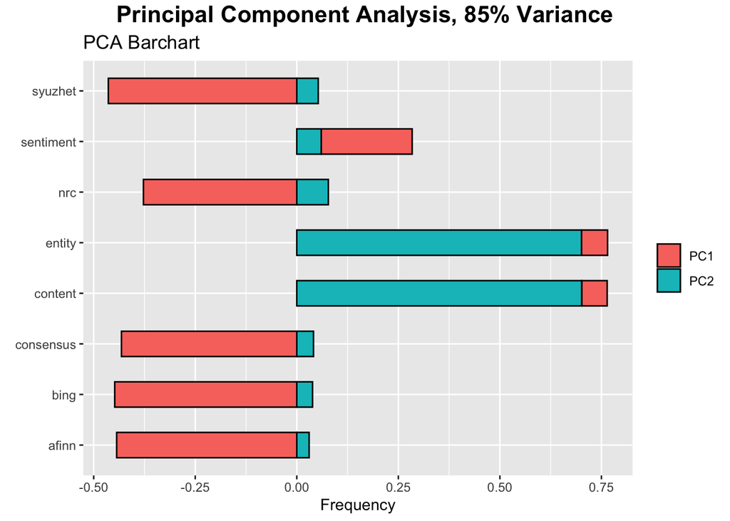

```r
pca_plot(train_df, pct = .85, which = 'bar')
```

Two columns, `content` and `entity`, have a 97% correlation. I had already hoped that `content` is unnecessary with the additional sentiment columns. `bing`, `syuzhet`, and `afinn` all correlate strongly (80+%), `nrc` appears to be an outsider. Alas, evidently nothing correlates strongly with `sentiment`.

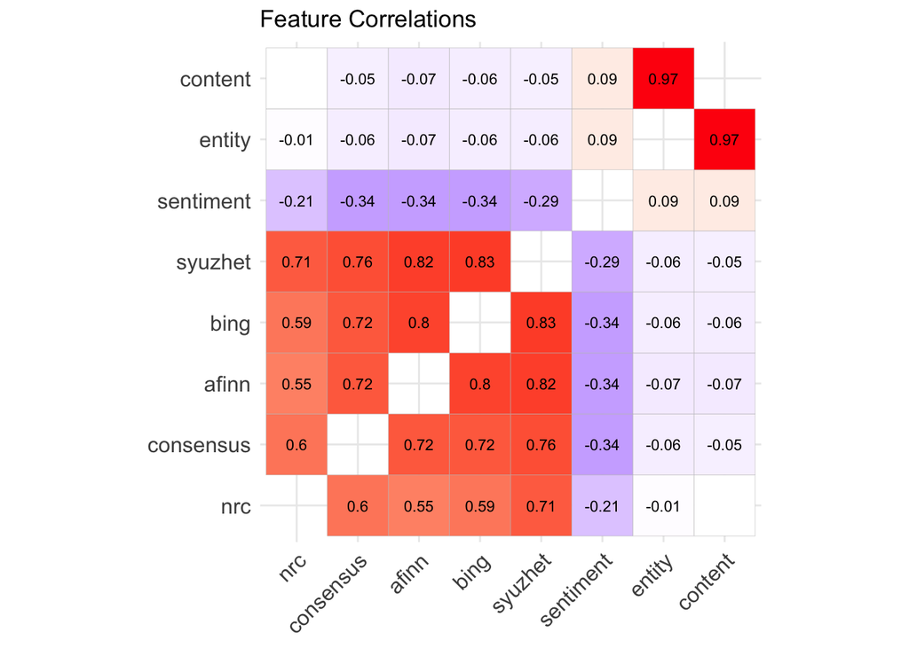

```r
corr_plot(train_df)
```

Conclusion: `pca` and `corr` may be good `preProcess` options for `train`. Defaults for `preProcess` are `thresh = .95` for `pca` and `cutoff = .9` for `corr`. I will also consider dropping `nrc`, or at least omitting it via formula; and the same with `content`.

# 6 Data Cleanup

Here I convert the remaining non-numeric data to numbers; check whether `content` is still necessary given the summarized lexicon sentiments; whether all the new lexicon sentiment columns are necessary; and check again for resulting duplicates.

## 6.1 Making it Numeric

I have cycled through this process numerous times. Once, dropping `content` had comparable accuracy, so I did. Another time, it lowered accuracy by %10 so I did not - but then hit the 16GB vector limit. Here I drop it regardless, and then convert `entitity` and `sentiment` to numeric.

While at it, I round `syuzhet` to three decimals, which in turn introduces tens of duplicates.

```r
unq_sentiments <- unique(c(train_df$sentiment, test_df$sentiment))
unq_entities   <- unique(c(train_df$entity, test_df$entity))

train_df <- train_df |> mutate(
    content   = NULL,
    sentiment = match(sentiment, unq_sentiments) -2,
    entity    = match(entity, unq_entities),
    syuzhet   = round(syuzhet, 3)
)
test_df <-test_df |> mutate(
    content   = NULL,
    sentiment = match(sentiment, unq_sentiments) -2,
    entity    = match(entity, unq_entities),
    syuzhet   = round(syuzhet, 3)
)

vanilla_classification()
```

Ranger Classification Metrics - Accuracy %80.80; ranger time 13.94(s)

| Class | Prevalence | Sensitivity | Specificity | Precision | F1 |
| --- | --- | --- | --- | --- | --- |
| Class: -1 | 0.277 | 0.755 | 0.927 | 0.798 | 0.776 |
| Class: 0 | 0.457 | 0.834 | 0.853 | 0.826 | 0.830 |
| Class: 1 | 0.266 | 0.820 | 0.920 | 0.787 | 0.803 |

## 6.2 Partitioning

Here I partition into train/test, after tucking aside full copies for later. Note, it is extremely tempting to drop duplicate rows, now about 53%(!) but accuracy plummets.

```r
train_org <- train_df
test_org  <- test_df

index     <- createDataPartition(y = train_df$sentiment, times = 1, p = 0.5, list = FALSE)
train_df  <- train_df[index,]
test_df   <- train_df[-index,]

vanilla_classification()
```

Ranger Classification Metrics - Accuracy %80.24; ranger time 5.63(s)

| Class | Prevalence | Sensitivity | Specificity | Precision | F1 |
| --- | --- | --- | --- | --- | --- |
| Class: -1 | 0.278 | 0.743 | 0.934 | 0.813 | 0.776 |
| Class: 0 | 0.419 | 0.855 | 0.824 | 0.778 | 0.815 |
| Class: 1 | 0.303 | 0.784 | 0.932 | 0.834 | 0.808 |

## 6.3 Accuracy without ‘nrc’

```r
vanilla_classification(
    .train = train_df |> select(-c(nrc)),
    .test =  test_df  |> select(-c(nrc))
)
```

Ranger Classification Metrics - Accuracy %75.78; ranger time 5.58(s)

| Class | Prevalence | Sensitivity | Specificity | Precision | F1 |
| --- | --- | --- | --- | --- | --- |
| Class: -1 | 0.278 | 0.689 | 0.923 | 0.774 | 0.729 |
| Class: 0 | 0.419 | 0.819 | 0.786 | 0.733 | 0.774 |
| Class: 1 | 0.303 | 0.737 | 0.911 | 0.784 | 0.759 |

## 6.4 Accuracy without ‘afinn’

```r
vanilla_classification(
    .train = train_df |> select(-c(afinn)),
    .test =  test_df  |> select(-c(afinn)))
```

Ranger Classification Metrics - Accuracy %70.66; ranger time 4.74(s)

| Class | Prevalence | Sensitivity | Specificity | Precision | F1 |
| --- | --- | --- | --- | --- | --- |
| Class: -1 | 0.278 | 0.652 | 0.897 | 0.710 | 0.680 |
| Class: 0 | 0.419 | 0.763 | 0.750 | 0.687 | 0.723 |
| Class: 1 | 0.303 | 0.679 | 0.894 | 0.736 | 0.707 |

## 6.5 Accuracy without ‘bing’

```r
vanilla_classification(
    .train = train_df |> select(-c(bing)),
    .test =  test_df  |> select(-c(bing))
)
```

Ranger Classification Metrics - Accuracy %78.83; ranger time 5.45(s)

| Class | Prevalence | Sensitivity | Specificity | Precision | F1 |
| --- | --- | --- | --- | --- | --- |
| Class: -1 | 0.278 | 0.733 | 0.931 | 0.803 | 0.766 |
| Class: 0 | 0.419 | 0.842 | 0.817 | 0.768 | 0.803 |
| Class: 1 | 0.303 | 0.765 | 0.921 | 0.808 | 0.786 |

## 6.6 Accuracy without ‘syuzhet’

```r
vanilla_classification(
    .train = train_df |> select(-c(syuzhet)),
    .test =  test_df  |> select(-c(syuzhet))
)
```

Ranger Classification Metrics - Accuracy %67.10; ranger time 4.33(s)

| Class | Prevalence | Sensitivity | Specificity | Precision | F1 |
| --- | --- | --- | --- | --- | --- |
| Class: -1 | 0.278 | 0.583 | 0.899 | 0.689 | 0.631 |
| Class: 0 | 0.419 | 0.733 | 0.716 | 0.650 | 0.689 |
| Class: 1 | 0.303 | 0.666 | 0.870 | 0.690 | 0.678 |

## 6.7 Accuracy without ‘consensus’

```r
vanilla_classification(
    .train = train_df |> select(-c(consensus)),
    .test  = test_df  |> select(-c(consensus))
)
```

Ranger Classification Metrics - Accuracy %84.76; ranger time 6.56(s)

| Class | Prevalence | Sensitivity | Specificity | Precision | F1 |
| --- | --- | --- | --- | --- | --- |
| Class: -1 | 0.278 | 0.805 | 0.950 | 0.862 | 0.832 |
| Class: 0 | 0.419 | 0.892 | 0.859 | 0.820 | 0.854 |
| Class: 1 | 0.303 | 0.826 | 0.951 | 0.880 | 0.852 |

## 6.8 Dropping ‘bing’ and ‘consensus’

Accuracy is stable to improved without `bing` and `consensus` - I drop

```r
train_df$bing  <- train_df$consensus  <- NULL
test_df$bing   <- test_df$consensus   <- NULL
train_org$bing <- train_org$consensus <- NULL
test_org$bing  <- test_org$consensus  <- NULL

vanilla_classification()
```

Ranger Classification Metrics - Accuracy %82.78; ranger time 6.51(s)

| Class | Prevalence | Sensitivity | Specificity | Precision | F1 |
| --- | --- | --- | --- | --- | --- |
| Class: -1 | 0.278 | 0.786 | 0.944 | 0.843 | 0.813 |
| Class: 0 | 0.419 | 0.868 | 0.851 | 0.808 | 0.837 |
| Class: 1 | 0.303 | 0.811 | 0.935 | 0.845 | 0.828 |

# 7 Initial Multi-Model Framework

Here I create functions for making predictions, calculating accuracy, running individual models, tracking results, and easily running them all together. The goal is to run numerous models and then narrow down to the most accurate one or few.

## 7.1 Predictions and Accuracy

Below are functions to make predictions and calculate accuracy, using the [ellipsis](https://cran.r-project.org/web/packages/ellipsis/ellipsis.pdf) argument to allow model nuances to be passed in.

```r
predictions <- function(model, test_df, type = 'class') {
    tryCatch({
        .pred <- predict(model, test_df, type = type)
    },
    error = function(e) {
        print(c(Model = model, error = e))
    },
    finally = {
        if(!is.atomic(.pred)) {
            .pred <- .pred$predictions
        }
        return(.pred)
    })
}

accuracy <- function(model, test_df, ...) {
    tryCatch({
        .pred <- predictions(model, test_df, ...)
        .cm   <- confusionMatrix(.pred, as.factor(test_df$sentiment))
    },
    error = function(e) {
        print(c(Model = model, error = e))
    },
    finally = {
        if (!exists('.cm')) {
            return(NA)
        }
        else {
            return(round(100*.cm$overall[['Accuracy']],2))
        }
    })
}
```

## 7.2 Formula and Models

And here, a basic formula; and a function for each model plus the type for the underlying `predict` - generally ‘class’ or ‘response’.

```r
fc <- as.formula(factor(sentiment) ~ .)
models <- list(
    ranger       = list(
        FUNC = function(...) { ranger(...) },
        TYPE = 'response'
    ),
    randomForest = list(
        FUNC = function(...) { randomForest(..., ntree = 20) },
        TYPE = 'response'
    ),
    knn3         = list(
        FUNC = function(...) { knn3(...) },
        TYPE = 'class'
    )
)
```

**Notes:**

1. Originally, I had six models - the above three plus `multinom`, `native_bayes`, and `avNNet`. I eventually pared it down to shave execution time.
2. `ranger` was uniquely problematic here. Originally, rather than `TYPE`, I set this up as `extraArgs` with a value of `c(type = 'class')` for example, or `NULL` if the underlying default was sufficient. But `ranger` gave, *Error: Expecting a single value: [extent=0]* when `extraArgs` was `NULL`; and *Error: Not compatible with requested type: [type=character; target=logical]* when `extraArgs` was `c(type = 'response')`. All other models behaved as expected, with a key-value pair or `NULL`.

## 7.3 Model Runner

Finally, a function to actually run the models and accumulate metrics.

```r
.run_model <- function(cfg, .formula, .train, .test) {
    FUNC <- cfg$FUNC
    TYPE <- cfg$TYPE
    accuracy(
        get("FUNC")(.formula, .train),
        .test, type = TYPE
    )
}

run_models <- function(
        .models  = models,
        .formula = fc,
        .train   = train_df,
        .test    = test_df
    ) {
        results <- sapply(names(.models), function(model) {
            .run_model(.models[[model]], .formula, .train, .test)
        })
        names(results) <- names(.models)
        return(results)
}
```

## 7.4 Metrics Summary

Below, a function to display the metrics. At the moment, the expectation is that the named vector from `run_models` will be bound with an initial column of meaningful labels.

```r
display_summary <- function(.data) {
    .data |>
        dplyr::rename(` ` = c(1)) |>
        datatable(
            rownames = FALSE,
            options  = list(
                dom        = 't',
                pageLength = nrow(.data)
            )
        )
}
```

```r
baselines <- run_models()
baselines |>
    as.data.frame() |>
    arrange(desc(baselines)) |>
    kable(col.names = c('Model', 'Accuracy')) |>
    kable_styling(full_width = FALSE, position = 'left')
```

| Model | Accuracy |
| --- | --- |
| ranger | 82.95 |
| randomForest | 81.54 |
| knn3 | 66.60 |

# 8 Second Multi-Model Framework - train()

## 8.1 Models and Tuning

I will stick with `ranger` and add in `Rborist` and `treebag`.

First, I define a list of NULL `trControl`, `tuneGrid`, and `preProcess` objects (and maybe `extraArgs`, but there is a rant coming up.)

```r
train_config <- list(
    ranger = list(
        trControl  = NULL,
        tuneGrid   = NULL,
        preProcess = NULL,
        extraArgs  = NULL
    ),
    Rborist = list(
        trControl  = NULL,
        tuneGrid   = NULL,
        preProcess = NULL,
        extraArgs  = NULL
    ),
    treebag = list(
        trControl  = NULL,
        tuneGrid   = NULL,
        preProcess = NULL,
        extraArgs  = NULL
    )
)
```

**Note:**

- Here again, I initially tried many more models in addition to the above: `svmRadial`, `mlp`, `xgbTree`, `gamLoess`, `rocc`, `glmnet`, `vglmContRatio`, `RFlda`, and `lssvmRadial`, chosen arbitrarily from this [caret list](https://rdrr.io/cran/caret/man/models.html) - but they all underperformed by 30% or more, and the execution time was intolerable.

## 8.2 Running the Models via Train

Here I write a function to generically execute a model via `train` and capture its accuracy. Arguments allow for alternate data sets, formula, model list, `trControl` and lists of `tuneGrid` objects.

```r
.train_model  <- function(
        model, cfg, .formula, .train, .test, bestTune,
       .trControl = NULL, .preProcess = NULL
) {
    tryCatch({
        fit <- (function(...) {
            caret::train(
                .formula,
                method     = model,
                data       = .train,
                trControl  = dplyr::coalesce(
                    .trControl,
                    trainControl(
                        method = 'repeatedcv',
                        number = 2,
                        p      = .5
                    )
                ),
                tuneGrid   = cfg$tuneGrid,
                preProcess = .preProcess,
                ...
            )
        })() # ideally, (...)
    }, error = function(e) {
        print(c(Model = model, error = e))
    },
    finally = {
        if (exists('fit')) {
            if (bestTune) {
                print(c(Model = model, bestTune = fit$bestTune))
            }
            return(accuracy(fit, .test, type = 'raw'))
        }
    })
}

train_models <- function(
    .config       = train_config,
    .formula      = fc,
    .train        = train_df,
    .test         = test_df,
    bestTune      = FALSE,
    .trControl    = NULL,
    .preProcess   = NULL
) {
    results <- sapply(names(.config), function(model) {
        .train_model(
            model, .config[[model]], .formula, .train, .test,
            bestTune, .trControl, .preProcess
        )
    })
    names(results) <- names(.config)
    return(results)
}
```

**Notes:**

1. The inner, anonymous function remains setup to accept extra arguments. I struggled mightily to send SOMETHING (key-value pair(s)) or NOTHING (i.e. *not* `NULL`). The only workaround so far is calling it with or without extra arguments via if/else, defeating the purpose of the ellipsis.
2. I also got burned terribly here. Prior to wrapping in `tryCatch`, the function worked in most cases but died with some models for some parameters. Within `tryCatch`, I was getting nothing but `NA` - and a lot of them, even distilled down to one model. It seems `tryCatch` requires an explicit `return` statement, and that without it I was getting the value of the `finally` block…?

## 8.3 First Runs - Baseline

And now I run what I’ll consider a baseline.

```r
train_baselines <- train_models()
train_baselines |>
    as.data.frame() |>
    arrange(desc(baselines)) |>
    kable(col.names = c('Model', 'Accuracy')) |>
    kable_styling(full_width = FALSE, position = 'left')
```

| Model | Accuracy |
| --- | --- |
| ranger | 84.17 |
| Rborist | 84.65 |
| treebag | 84.24 |

## 8.4 Tuning the Models

Now I look for improvements via `tuneGrid`, `preProcess`, and `trainControl` options.

### 8.4.1 tuneGrid

I started with `tuneGrid` and ran the models once without any customization and captured their out-of-the-box best `tuneGrid` values; then repeated with various ranges around those values. This remains a manual and tedious step, and generally not very effective. Below are the values I settled upon after several iterations of nothing exciting.

```r
train_config <- list(
    ranger = list(
        tuneGrid = expand.grid(
            mtry          = 3,
            splitrule     = 'extratrees',
            min.node.size = 2
        )
    ),
    Rborist = list(
        tuneGrid = expand.grid(
            predFixed = 2,
            minNode   = 3
        )
    ),
    treebag = list(
    )
)

bestTunes <- train_models() #bestTune=TRUE)
bind_rows(baselines, train_baselines, bestTunes) |>
    as.data.frame() |>
    kable() |>
    kable_styling(full_width = FALSE, position = 'left') |>
    pack_rows(
        index = c('baseline' = 1, 'train() baseline' = 1, 'bestTune' = 1),
        label_row_css = 'text-align:center; background-color: #666; color: #fff;'
    )
```

| ranger | randomForest | knn3 | Rborist | treebag |
| --- | --- | --- | --- | --- |
| **baseline** |  |  |  |  |
| 82.95 | 81.54 | 66.6 | NA | NA |
| **train() baseline** |  |  |  |  |
| 84.17 | NA | NA | 84.65 | 84.24 |
| **bestTune** |  |  |  |  |
| 84.07 | NA | NA | 84.45 | 84.23 |

This is terribly inconsistent, despite setting seed. Ironically, `treebag` tends to change most, in either direction, despite *not* having a `tuneGrid`. At least once, `ranger` plummeted 26% despite its `tuneGrid` permutations including the values of the initial `bestTune`! At any rate, there is generally not enough movement to consider worthwhile.

### 8.4.2 trainControl

Here I nullify the `trainGrid` settings and look at various `trainControl` methods.

```r
train_config <- list(
    ranger = list(
        tuneGrid = NULL
    ),
    Rborist = list(
        tuneGrid = NULL
    ),
    treebag = list(
        tuneGrid = NULL
    )
)

boot_results <- bind_rows(
    train_models(.trControl = trainControl(
        method = 'boot', number = 2)),
    train_models(.trControl = trainControl(
        method = 'boot632', number = 2)),
    train_models(.trControl = trainControl(
        method = 'optimism_boot', number = 2)),
    train_models(.trControl = trainControl(
        method = 'boot_all', number = 2))
)

cv_results <- bind_rows(
    train_models(.trControl = trainControl(
        method = 'cv', p = .5, repeats = 2, number = 2)),
    train_models(.trControl = trainControl(
        method = 'repeatedcv', p = .5, repeats = 2, number = 2)),
    train_models(.trControl = trainControl(
        method = 'LGOCV', p = .5, repeats = 2, number = 2))
)

train_summary <- bind_cols(
    c(
        'boot', 'boot632', 'optimism_boot', 'boot_all',
        'cv', 'repeatedcv', 'LGOCV'
    ),
    bind_rows(boot_results, cv_results)
)

display_summary(train_summary)
```

|  | ranger | Rborist | treebag |
| --- | --- | --- | --- |
| boot | 84.15 | 84.54 | 84.35 |
| boot632 | 84.09 | 84.46 | 84.22 |
| optimism_boot | 84.54 | 84.53 | 84.26 |
| boot_all | 84.21 | 84.44 | 84.25 |
| cv | 84.23 | 84.51 | 84.25 |
| repeatedcv | 79.81 | 84.54 | 84.25 |
| LGOCV | 82.89 | 84.5 | 84.24 |

**Note:**

- There are also ‘adaptive_boot’, ‘adaptive_cv’, and ‘adaptive_LGOCV’. They produced errors - *adaptive$min should be less than 2*, and then *adaptive$min should be greater than 1*, and finally *For adaptive resampling, there needs to be more than one tuning parameter for evaluation*, with `adaptive = list(min = 2, ...)`, `min = 1`, and `min = 1.1`. Infuriatingly, running the same on the command line worked. But for the good, this inspired `tryCatch`.

Conclusion - Again, not enough movement to consider worthwhile.

### 8.4.3 preProcess

```r
pre_results <- bind_rows(
    train_models(.preProcess = c('BoxCox')),
    train_models(.preProcess = c('YeoJohnson')),
    train_models(.preProcess = c('expoTrans')),
    train_models(.preProcess = c('spatialSign')),
    train_models(.preProcess = c('pca'))
)
pre_summary <- bind_cols(
    c('BoxCox', 'YeoJohnson', 'expoTrans', 'spatialSign', 'pca'),
    pre_results
)

display_summary(pre_summary)
```

|  | ranger | Rborist | treebag |
| --- | --- | --- | --- |
| BoxCox | 79.95 | 84.53 | 84.18 |
| YeoJohnson | 82.97 | 84.54 | 84.33 |
| expoTrans | 84.16 | 84.41 | 84.11 |
| spatialSign | 84.56 | 84.46 | 84.34 |
| pca | 84.56 | 84.6 | 84.35 |

**Notes:**

There are numerous other `preProcess` methods:

- I ruled out `zv` and `nzv`, as any column here with little variance is expected.
- `knnImpute`, `bagImpute`, and `medianImpute` are not applicable as there are no missing values.
- I looked further into `conditionalX`. Its description in `preProcess` help left me uncertain, and I found a fuller description alongside [nearZeroVar](https://search.r-project.org/CRAN/refmans/caret/html/nearZeroVar.html). In summary, it looks at the distribution of each predictor conditioned on the levels of the outcome, and identifies any predictor that is sparse within groups of the outcome.

  I ran `checkConditionalX` as follows - and no predictor was identified. (I will add this to my early analysis checklist, along with outliers, NAs, duplicates, etc .)

  ```r
  checkConditionalX(train_df |> select(-c(sentiment)), train_df$sentiment)
  ```

  ```
  ## integer(0)
  ```

# 9 Final Validation

```r
train_config <- list(
    ranger = list(
        tuneGrid = NULL
    ),
    Rborist = list(
        tuneGrid = NULL
    ),
    treebag = list(
        tuneGrid = NULL
    )
)

final_results <- train_models(
    .train = train_org,
    .test  = test_org
)

final_summary <- bind_cols(
    c('baseline', 'bestTune', 'trainControl', 'preProcess', 'finalValidation'),
    bind_rows(
        baselines,
        bestTunes,
        c(
            ranger  = max(train_summary[['ranger']]),
            Rborist = max(train_summary[['Rborist']]),
            treebag = max(train_summary[['treebag']])
        ),
        c(
            ranger  = max(pre_results[['ranger']]),
            Rborist = max(pre_results[['Rborist']]),
            treebag = max(pre_results[['treebag']])
        ),
        final_results
    )
)

display_summary(final_summary)
```

|  | ranger | randomForest | knn3 | Rborist | treebag |
| --- | --- | --- | --- | --- | --- |
| baseline | 82.95 | 81.54 | 66.6 |  |  |
| bestTune | 84.07 |  |  | 84.45 | 84.23 |
| trainControl | 84.54 |  |  | 84.54 | 84.35 |
| preProcess | 84.56 |  |  | 84.6 | 84.35 |
| finalValidation | 83.6 |  |  | 82.9 | 83.2 |

# 10 Conclusions

1. The winner is inconclusive; the numbers changes per run. (Did I NOT set seed?) I only see Python solutions on Kaggle, and they generally have train accuracy in the mid-90s and validation accuracy in the mid-80s. This Rmd matches that, albeit erratically…
2. My primary goal was continued learning:
   - Paragraph-based sentiments was the big lesson.
   - I gained more comfort with `tryCatch` and `...`, but both came with surprises. I need to learn more, especially whether there is an idiomatic method of, for example, reading *optional* parameters/values from a config file and passing to an ellipses. Perhaps it is just that simple, but my experience here says otherwise.
   - I had a note to myself to try dtree but when trying to install it I see that *Package ‘dtree’ was removed from the CRAN repository.*
3. I had *many* troubles with this project - in addition to lengthy execution times against the full training set:
   - Once, transitioning between Visual and Source editing modes, the closing backticks were removed from almost every code block, preventing Visual mode.
   - Many times, a block of code failed or ran extremely slowly in RStudio but fine in the console - *or vice versa*.
   - Once, manually running code blocks from the top down, each kickoff scrolled the document back to the top; forcing me to scroll further and further down to run the next block. What is that?!
   - Already mentioned, accuracy changed wildly without plausible explanation, despite seed. Against the partitioned halves, accuracy fluctuated from the mid-60s to mid-90s?!
   - I very often had to run code blocks *twice* in this Rmd: Often, a spurious second box of (empty) output is created, and disappears on subsequent run. Occasionally, the desired output is cropped and unscrollable - and self-corrects on a subsequent run. Occasionally, there is no output for no apparent reason - in which case I can often run just the output-producing line(s), proving that everything else worked.
4. Once again, most effort was for naught, other than learning. The only thing that helped in a measurable way was the one obvious need - calculating sentiments.

# 11 References

https://rpubs.com/chelseyhill/676279

https://search.r-project.org/CRAN/refmans/caret/html/nearZeroVar.html

https://cran.r-project.org/web/packages/ranger/ranger.pdf

https://github.com/mjockers/syuzhet/blob/master/R/syuzhet.R

# 12 Appendix

## 12.1 RandomForest Decision Tree

I like to end with a look at a model’s decision tree. I’ve never seen one with such symmetry! I can imagine the difficult choices.

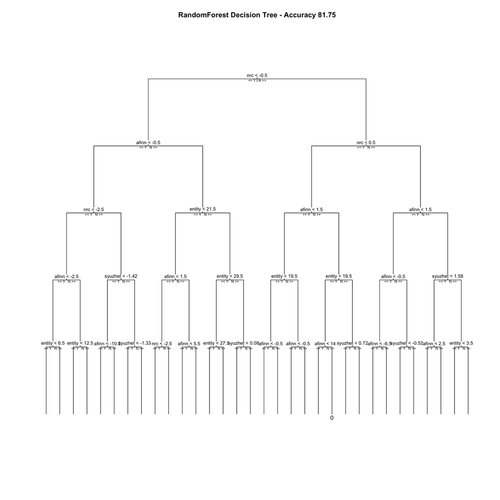

```r
fit <- randomForest(
    factor(sentiment) ~ .,
    train_df,
    ntree = 20
)
simplest_tree <- which.min(fit$forest$ndbigtree)
fit$forest$xbestsplit <- round(fit$forest$xbestsplit, 2)  # 'digits' workaround
plot.getTree(
    fit,
    k     = simplest_tree,
    depth = 6,
    main  = sprintf(
        'RandomForest Decision Tree - Accuracy %.2f',
        accuracy(fit, test_df)
    )
)
```

## 12.2 Case-Specific Random Forests

Reading further about `ranger`, I noticed `csrf` and thought I’d try it. Alas, running against the full train/validation sets gives, *Error in table(data, reference, dnn = dnn, …) : all arguments must have the same length*. That seems odd - is it uncommon to have different sized data sets…?

```r
pred <- csrf(
    factor(sentiment) ~ .,
    training_data = train_df,
    test_data     = test_df,
    params1       = list(num.trees = 50, mtry = 4),
    params2       = list(num.trees = 5)
)

cm <- confusionMatrix(pred, factor(test_df$sentiment))
cm$overall[['Accuracy']]
```

```
## [1] 0.8445435
```